# A of E D final project

Rozy Bathrick

2022-11-21

# Delomys data analysis

## Data Exploration and Q1-4

First we look at the body length and mass of these little mice in summary and run a shapiro test to see if the variance is normally distributed

```r
require(here)
here()
```

```
## [1] "/Users/rosalynbathrick/Library/CloudStorage/OneDrive-UniversityofMassachusetts/environmental_data"
```

```r
delo<-read.csv(here("data", "delomys.csv"))
summary(delo$body_mass)
```

```
##    Min. 1st Qu.  Median    Mean 3rd Qu.    Max.
##    5.00   35.00   43.00   44.06   54.00  105.00
```

```r
summary(delo$body_length)
```

```
##    Min. 1st Qu.  Median    Mean 3rd Qu.    Max.
##    49.0   106.0   116.0   114.7   124.0   265.0
```

```r
shapiro.test(delo$body_mass)
```

```
##
##  Shapiro-Wilk normality test
##
## data:  delo$body_mass
## W = 0.99506, p-value = 4.33e-05
```

```r
shapiro.test(delo$body_length)
```

```
##
##  Shapiro-Wilk normality test
##
## data:  delo$body_length
## W = 0.87609, p-value < 2.2e-16
```

### Graphical Exploration

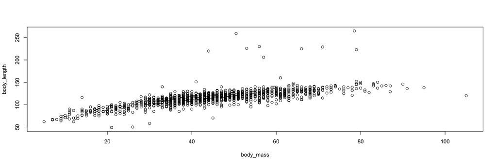

```r
plot(body_length ~ body_mass, data=delo)
```

Histogram of body Mass

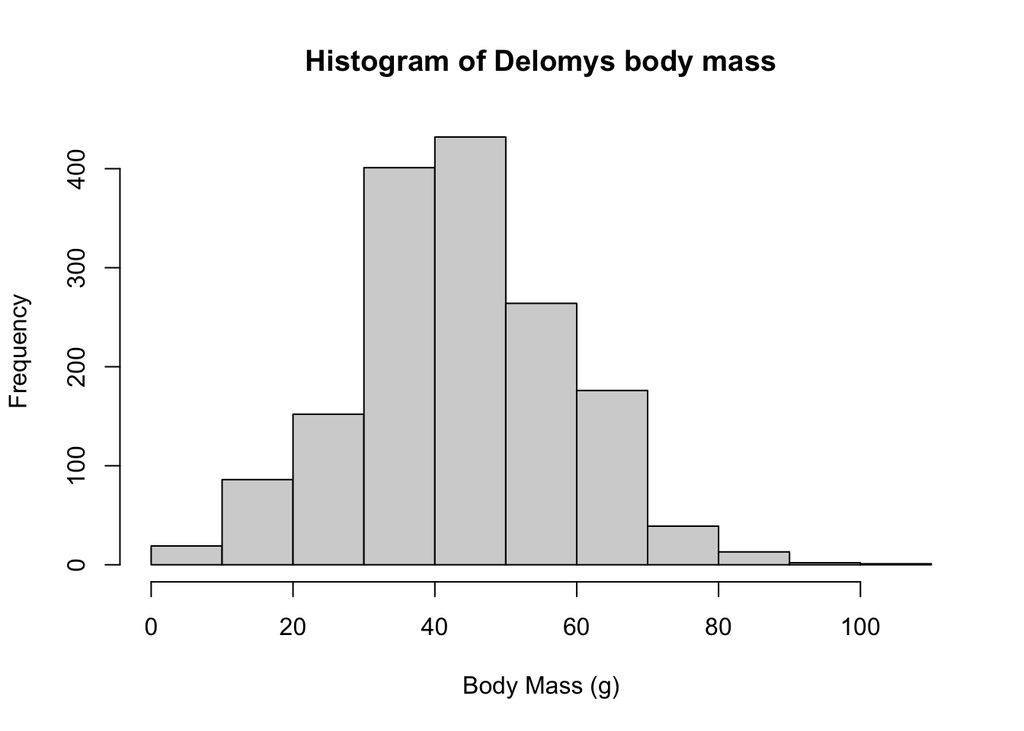

```r
hist(delo$body_mass, main="Histogram of Delomys body mass", xlab="Body Mass (g)")
```

Histogram of body length

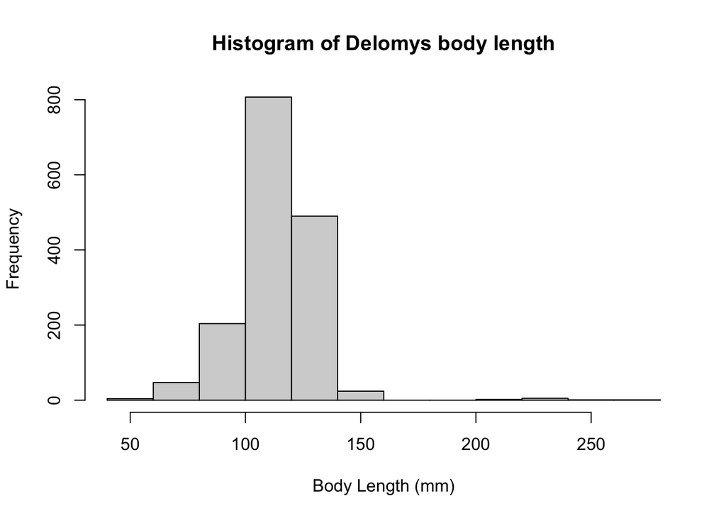

```r
hist(delo$body_length, main="Histogram of Delomys body length", xlab="Body Length (mm)")
```

A conditional boxplot of body mass, conditioned on species (column binomial)

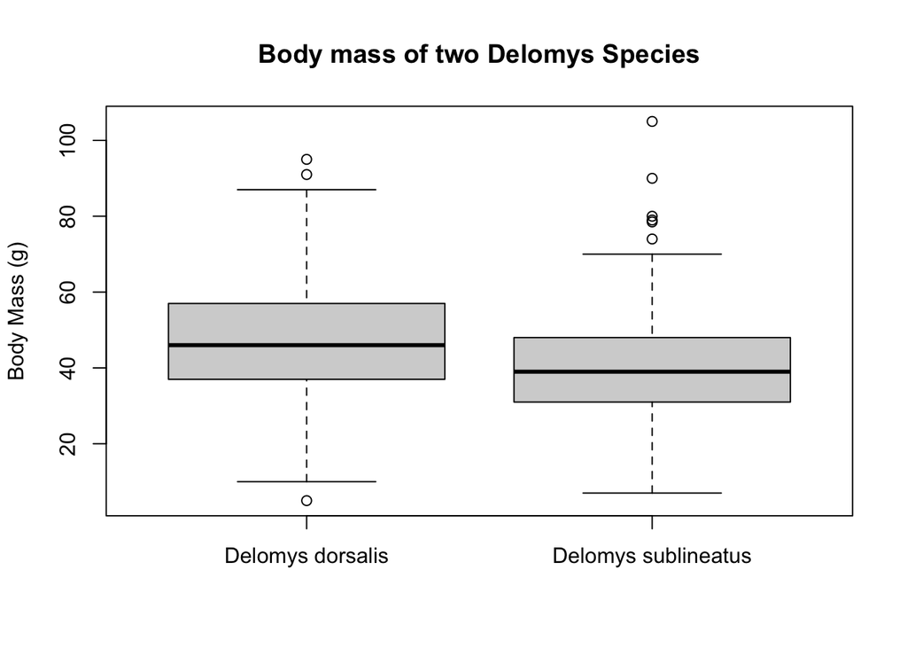

```r
boxplot(delo$body_mass ~ delo$binomial, main="Body mass of two Delomys Species", xlab=" ", ylab="Body Mass (g)")
```

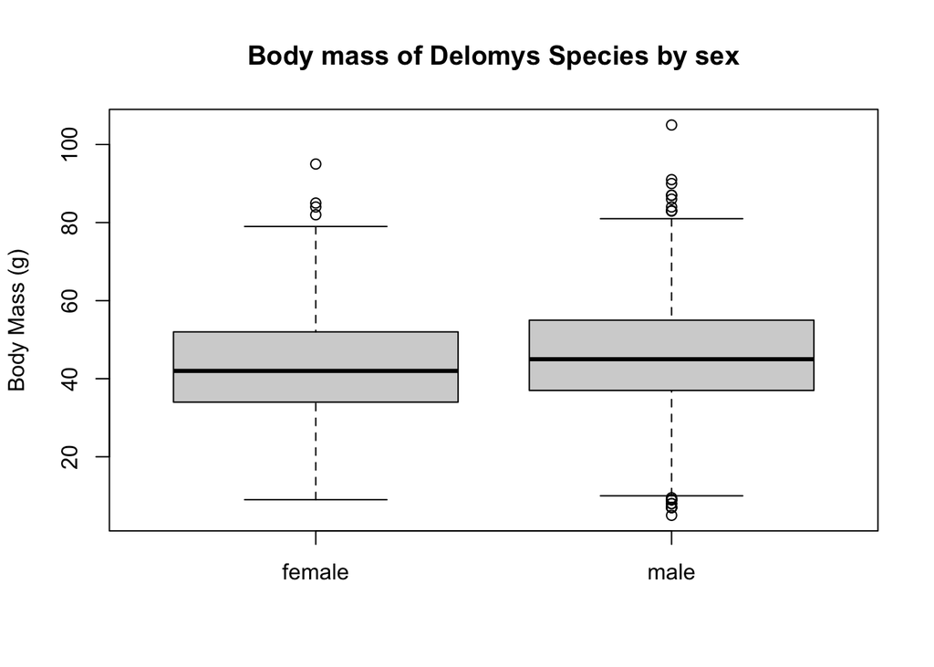

```r
boxplot(delo$body_mass ~ delo$sex, main="Body mass of Delomys Species by sex", xlab=" ", ylab="Body Mass (g)")
```

A conditional boxplot of body mass, conditioned on both species and sex

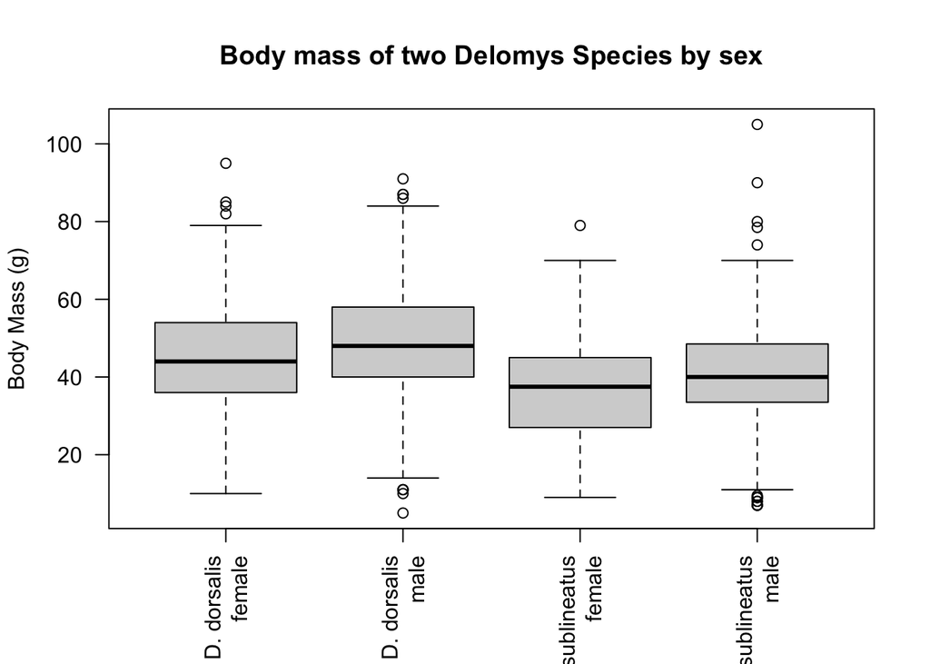

```r
boxplot(delo$body_mass ~ delo$sex+ delo$binomial, main="Body mass of two Delomys Species by sex", ylab="Body Mass (g)", xlab=" ", las=2, names=(c("D. dorsalis\n female", "D. dorsalis\nmale", "D. sublineatus\nfemale", "D. sublineatus\nmale")))
```

#### Q1 (2 pts.): Qualitatively describe the relationship between body mass and length.

A: There does seem to be a relationship - it looks logarithmic to me, with diminishing returns in body length as the body mass increases.

#### Q2 (2 pts.): Qualitatively describe the shapes of the histograms.

A: The histograms are unimodal, and appear to be mostly normally distributed with mild skew.

#### Q3 (3 pts.): Using both the histograms and normality tests, do you think the (unconditioned) body masses and body length are normally-distributed?

A: Though the histograms look only slightly asymmetric, the shapiro test returns a low p-value, thus we reject the null that they are normally distributed (they are not normally-distributed)

## Model Building and Diagnostic Q5-6

```r
#Model 1: simple linear regression body_length ~ body_mass
fit1=lm(body_length~body_mass, data=delo)

#Model 2: 1-way ANOVA body_mass ~ sex
fit2=lm(body_mass~sex, data=delo)

#Model 3: 1-way ANOVA body_mass ~ binomial
fit3=lm(body_mass~binomial, data=delo)

#Model 4: 2-way additive ANOVA body_mass ~ sex + binomial
fit4=lm(body_mass~sex+binomial, data=delo)

#Model 5: 2-way factorial ANOVA body_mass ~ sex * binomial
fit5=lm(body_mass~sex*binomial, data=delo)
```

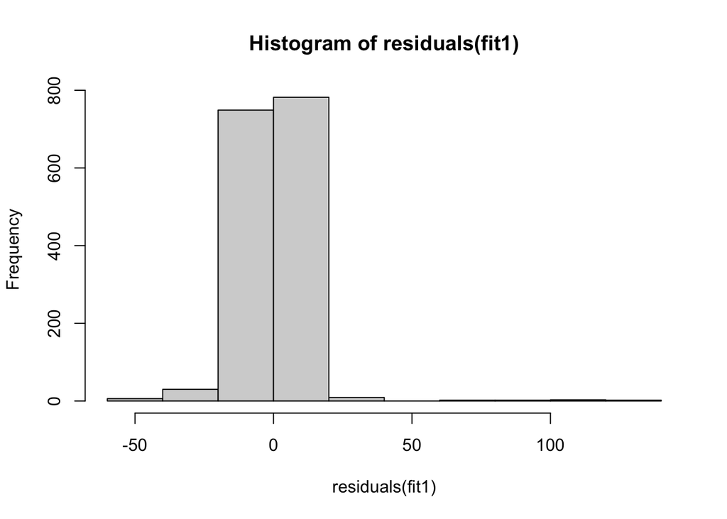

```r
hist(residuals(fit1))
```

```r
shapiro.test(residuals(fit1)) #not normally distrib
```

```
##
##  Shapiro-Wilk normality test
##
## data:  residuals(fit1)
## W = 0.73462, p-value < 2.2e-16
```

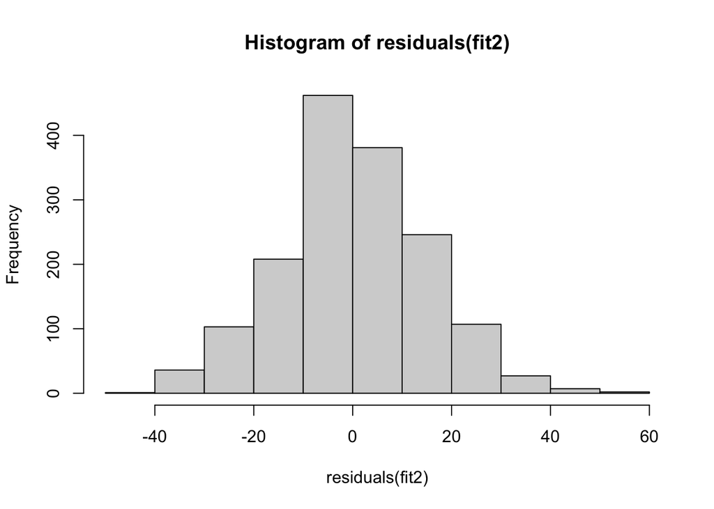

```r
hist(residuals(fit2))
```

```r
shapiro.test(residuals(fit2)) #not normally distrib
```

```
##
##  Shapiro-Wilk normality test
##
## data:  residuals(fit2)
## W = 0.99563, p-value = 0.0001541
```

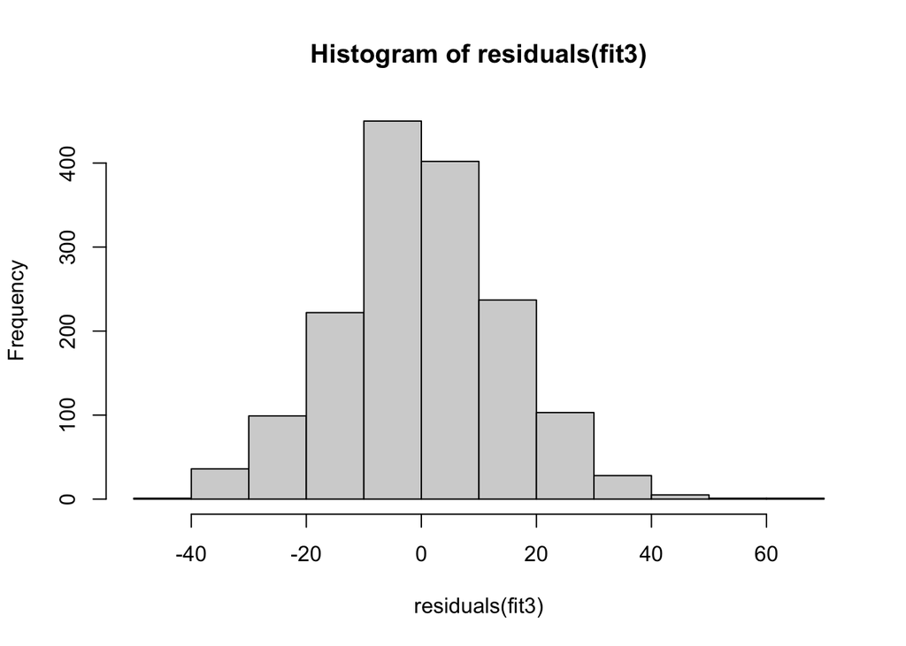

```r
hist(residuals(fit3))
```

```r
shapiro.test(residuals(fit3)) #not normally distrib
```

```
##
##  Shapiro-Wilk normality test
##
## data:  residuals(fit3)
## W = 0.99535, p-value = 8.103e-05
```

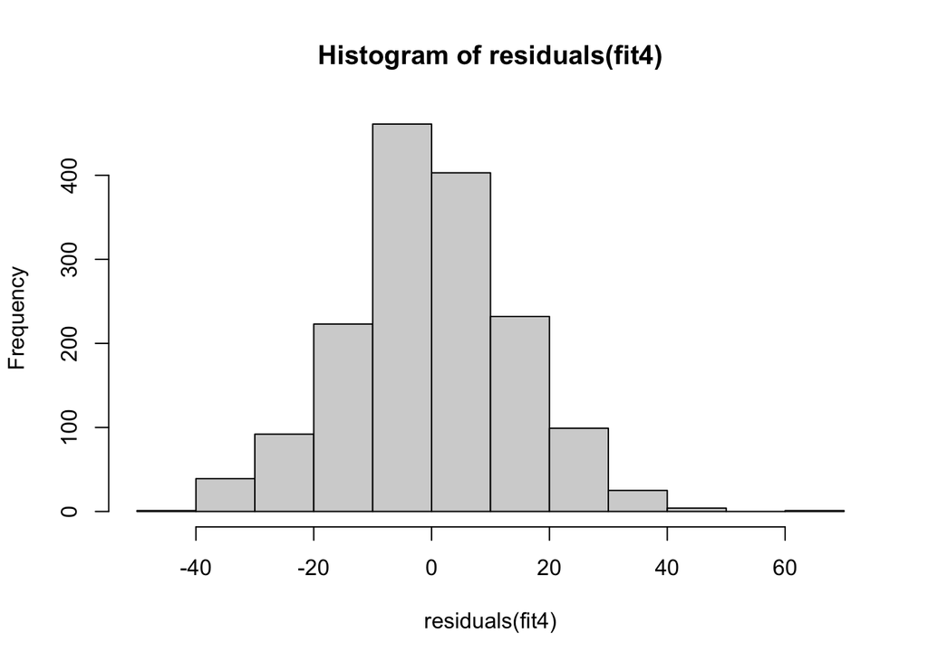

```r
hist(residuals(fit4))
```

```r
shapiro.test(residuals(fit4)) #not normally distrib
```

```
##
##  Shapiro-Wilk normality test
##
## data:  residuals(fit4)
## W = 0.99525, p-value = 6.805e-05
```

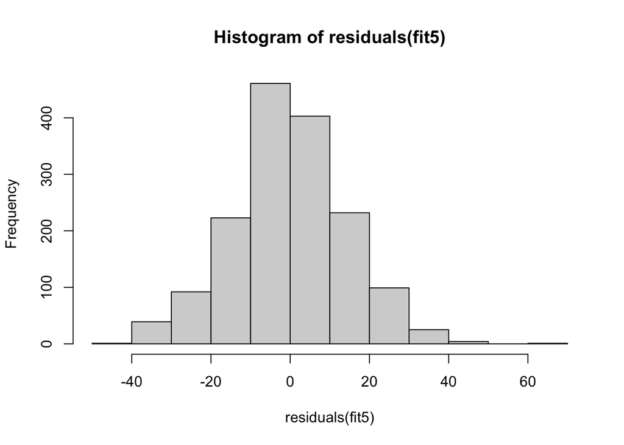

```r
hist(residuals(fit5))
```

```r
shapiro.test(residuals(fit5)) #not normally distrib
```

```
##
##  Shapiro-Wilk normality test
##
## data:  residuals(fit5)
## W = 0.99526, p-value = 6.816e-05
```

#### Q5 (2 pts.): What do you conclude about residual normality based on the numerical and graphical diagnostics?

A: The residuals are not normally distributed

#### Q6 (1 pt.): Are violations of the normality assumption equally severe for all the models?

A: No. Model 2: 1-way ANOVA explaining body mass by sex is the least severe in its violations, and the first Model is the most severe.

## Model Interpretation Q7-16

```r
summary(fit1)
```

```
##
## Call:
## lm(formula = body_length ~ body_mass, data = delo)
##
## Residuals:
##     Min      1Q  Median      3Q     Max
## -48.888  -5.398   0.104   4.859 138.663
##
## Coefficients:
##             Estimate Std. Error t value Pr(>|t|)
## (Intercept) 76.12466    0.91581   83.12   <2e-16 ***
## body_mass    0.87550    0.01969   44.46   <2e-16 ***
## ---
## Signif. codes:  0 '***' 0.001 '**' 0.01 '*' 0.05 '.' 0.1 ' ' 1
##
## Residual standard error: 11.67 on 1583 degrees of freedom
## Multiple R-squared:  0.5553, Adjusted R-squared:  0.5551
## F-statistic:  1977 on 1 and 1583 DF,  p-value: < 2.2e-16
```

#### Q8 (2 pts.): What is the expected body length of an an animal that weighs 100g?

```r
76.12466+(100*.87550)
```

```
## [1] 163.6747
```

```r
anova(fit2)
```

```
## Analysis of Variance Table
##
## Response: body_mass
##             Df Sum Sq Mean Sq F value    Pr(>F)
## sex          1   3062 3061.68  13.943 0.0001951 ***
## Residuals 1578 346507  219.59
## ---
## Signif. codes:  0 '***' 0.001 '**' 0.01 '*' 0.05 '.' 0.1 ' ' 1
```

```r
anova(fit3)
```

```
## Analysis of Variance Table
##
## Response: body_mass
##             Df Sum Sq Mean Sq F value    Pr(>F)
## binomial     1  21290 21289.7  102.08 < 2.2e-16 ***
## Residuals 1583 330164   208.6
## ---
## Signif. codes:  0 '***' 0.001 '**' 0.01 '*' 0.05 '.' 0.1 ' ' 1
```

```r
anova(fit4)
```

```
## Analysis of Variance Table
##
## Response: body_mass
##             Df Sum Sq Mean Sq F value    Pr(>F)
## sex          1   3062  3061.7  14.958 0.0001144 ***
## binomial     1  23727 23727.1 115.923 < 2.2e-16 ***
## Residuals 1577 322780   204.7
## ---
## Signif. codes:  0 '***' 0.001 '**' 0.01 '*' 0.05 '.' 0.1 ' ' 1
```

```r
anova(fit5)
```

```
## Analysis of Variance Table
##
## Response: body_mass
##                Df Sum Sq Mean Sq  F value    Pr(>F)
## sex             1   3062  3061.7  14.9489  0.000115 ***
## binomial        1  23727 23727.1 115.8500 < 2.2e-16 ***
## sex:binomial    1      1     0.8   0.0039  0.950442
## Residuals    1576 322779   204.8
## ---
## Signif. codes:  0 '***' 0.001 '**' 0.01 '*' 0.05 '.' 0.1 ' ' 1
```

#### Q10 (1 pt.): What is the base level for sex?

A: female

#### Q11 (1 pt.): What is the base level for binomial?

A: D. dorsalis

#### Q12 (1 pt.): Which sex is heavier?

A: male

#### Q13 (1 pt.): Which species is heavier?

A: D. dorsalis

#### Q14 (1 pt.): Are sex and species significant predictors for body mass?

A: Yes

#### Q15 (1 pt.): Is there a significant interaction?

A: No

#### Q16 (2 pts.): How dos the significance (as measured by p-value) of either of the main effects (sex and species) differ between the single-predictor models, the additive model, and the interactive model?

A: The significance of the species effect remains constant in all models, at < 2.2e-16 *** (one of the lowest numbers possible). The significance of the sex effect varies a bit, but the p-value remains very small - though never close to as small as the species effect.

## Model Comparison: Body Mass Q17-18

```r
##testing the goodness of fit with AIC value

AIC(fit2) #Model 2: 1-way ANOVA body_mass ~ sex
```

```
## [1] 13006.8
```

```r
AIC(fit3) #Model 3: 1-way ANOVA body_mass ~ binomial
```

```
## [1] 12966.36
```

```r
AIC(fit4) #Model 4: 2-way additive ANOVA body_mass ~ sex + binomial
```

```
## [1] 12896.73
```

```r
AIC(fit5) #Model 5: 2-way factorial ANOVA body_mass ~ sex * binomial
```

```
## [1] 12898.72
```

#### Q17 (1 pt.): Which two models have the lowest AIC?

A: Model 4: 2-way additive ANOVA body_mass ~ sex + binomial and Model 5: 2-way factorial ANOVA body_mass ~ sex * binomial

#### Q18 (4 pts.): Which of the two models with lowest AIC scores would you select?

Because there isn’t a huge difference in AIC between the last two, and we know that the difference between species is really the responsible effect, I would choose Model 4. This is a less complex model, and allows us to see the difference between sex and species effect on body mass.